# Exploratory Data Analysis

# Bivariate analysis (two variables at a time)

## Relationship between variables

Now that we have explored univarite, we can try to see relationships between two variables.

First, is there a relationship between `dep_delay` and `arr_delay`?

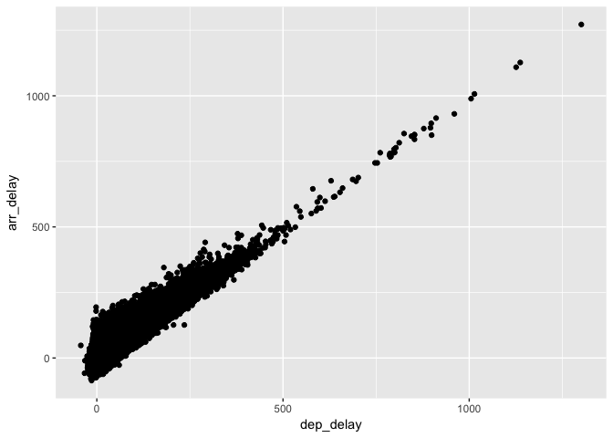

```r
# simple scatterplot departure delay versus
p.arr_dep1 = ggplot(na.omit(flights),aes(dep_delay,arr_delay)) +
  geom_point()
print(p.arr_dep1)
```

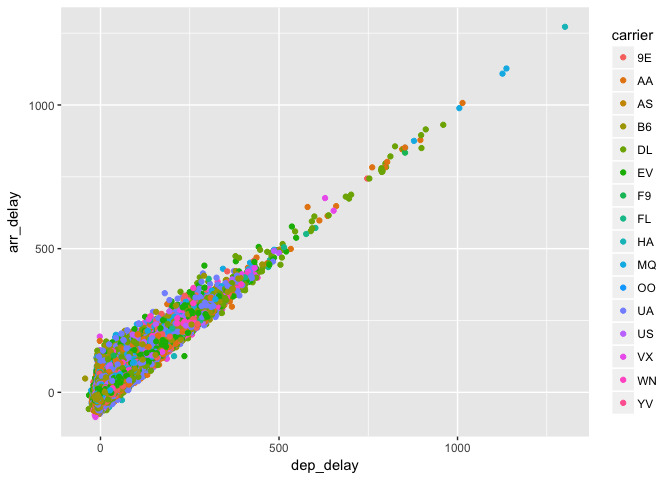

```r
# scatterplot with carrier company
p.arr_dep2 = ggplot(na.omit(flights),aes(dep_delay,arr_delay,colour=carrier)) +
  geom_point()
print(p.arr_dep2)
```

**Question**: Can you think of other relationships? Tip: to print all variables, type `glimpse(flights)`

## Multivariate analysis

We will keep that for a next lesson!

# Making hypothesis: a first step into regressions

## Hypothesis: delays are related to the distance traveled

From the Github repository of Andrew Bray > Say you’re curious about the relationship between the number of flights each plane made in 2013, the mean distance that each of those planes flew, and the mean arrival delay. You also want to exclude the edge cases from your analysis, so focus on the planes that have logged more than 20 flights and flown an average distance of less than 2000 miles. Please form the chain that creates this dataset.

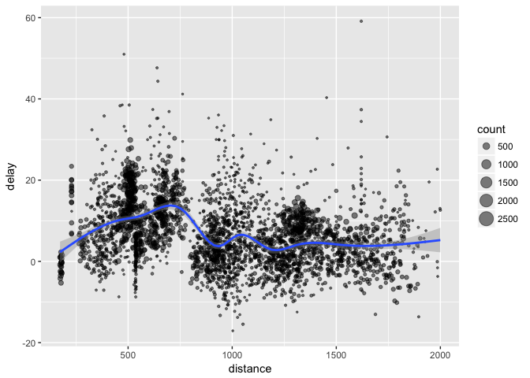

```r
arr_delay <- flights %>%
  group_by(tailnum) %>%
  summarise(
    count = n(),
    distance = mean(distance, na.rm = TRUE),
    delay = mean(arr_delay, na.rm = TRUE)) %>%
  filter(count > 20, distance < 2000)

p.delay <- ggplot(arr_delay, aes(distance, delay)) +
 geom_point(aes(size = count), alpha = 1/2) +
 geom_smooth() +
 scale_size_area()
print(p.delay)
```

```r
fit = lm(arr_delay ~ distance, data=na.omit(flights))

# show the summary of the model
summary(fit)
```

```
##
## Call:
## lm(formula = arr_delay ~ distance, data = na.omit(flights))
##
## Residuals:
##     Min      1Q  Median      3Q     Max
##  -87.20  -24.03  -11.84    7.19 1279.87
##
## Coefficients:
##               Estimate Std. Error t value Pr(>|t|)
## (Intercept) 10.8291976  0.1355211   79.91   <2e-16 ***
## distance    -0.0037523  0.0001058  -35.47   <2e-16 ***
## ---
## Signif. codes:  0 '***' 0.001 '**' 0.01 '*' 0.05 '.' 0.1 ' ' 1
##
## Residual standard error: 44.55 on 327344 degrees of freedom
## Multiple R-squared:  0.003828,   Adjusted R-squared:  0.003825
## F-statistic:  1258 on 1 and 327344 DF,  p-value: < 2.2e-16
```

# Conclusion

In this lesson, we have seen how to quickly explore and make hypothesis on a dataset using R and the powerful `tidyverse` collection of tools. This lesson combines well with the two lessons on simple plots and regressions. **Important note 1**: this lesson is meant to be the follow-up of Joeri’s lesson on plots in R [lesson: November 7th, 2017](https://github.com/ScienceParkStudyGroup/studyGroup/blob/gh-pages/lessons/20171107_Simple_plots_with_R_Joeri/20171107_simple_plots_with_r_session.Rmd). **Important note 2**: this lesson will be followed by a lesson on regression on [March 3rd by Emiel](https://github.com/ScienceParkStudyGroup/studyGroup/issues/19).

# To go deeper into Exploratory Data Analysis

- [Modern Dive](http://moderndive.com/index.html)
- [ggplot2 cookbook](http://www.cookbook-r.com/Graphs/)